# Project - University Enrollment

ERICK@Guru

2023

## Practical Exam - University Enrollment

**Instructions**

● Use Python or R to perform the tasks required.

● Write your solutions in the workspace provided from your certification page.

● Include all of the visualizations you create to complete the tasks.

Visualizations must be visible in the published version of the workspace. Links to external visualizations will not be accepted.

● You do not need to include code unless the question says you must.

● You must pass all criteria to pass this exam.

**The full criteria can be found here.**

Background: You are working as a data scientist at a local University. The university started offering online courses to reach a wider range of students. The university wants you to help them understand enrollment trends. They would like you to identify what contributes to higher enrollment. **In particular, whether the course type (online or classroom) is a factor.** 1

```r
#Import libraries
library(tidyverse)
library(dplyr)
library(corrplot)
library(VIM)
library(cowplot)
library(parsnip)
library(ggplot2)
library(janitor)
library(rsample)
library(e1071)#svm model
library(DataExplorer)
library(report)
library(lmtest)#test the model#harvtest(model) funtion we want p-value>0.05
# shapiro.test(residuals(model)) we want p-value>0.05
theme_set(theme_test())
library(tinytex)
library(bookdown)
library(rmarkdown)
```

```r
#Import dataset
enrol <-read_csv("university_enrollment_2306.csv")
head(enrol)
```

| course_id | course_type | year | enrollment_count | pre_score | post_score | pre_requirement | department |
| --- | --- | --- | --- | --- | --- | --- | --- |
| 1 | classroom | 2018 | 165 | 28.14 | 73 | Beginner | Science |
| 2 | classroom | 2020 | 175 | 79.68 | 86 | None | Science |
| 3 | online | 2016 | 257 | 57.24 | 80 | NA | Mathematics |
| 4 | online | 2013 | 251 | 97.67 | 75 | Beginner | Technology |
| 5 | classroom | 2019 | 165 | 39.75 | 76 | Beginner | Science |
| 6 | online | 2014 | 246 | 50.1 | 76 | Beginner | Math |

```r
glimpse(enrol)
```

```
## Rows: 1,850
## Columns: 8
## $ course_id        <dbl> 1, 2, 3, 4, 5, 6, 7, 8, 9, 10, 11, 12, 13, 14, 15, 16…
## $ course_type      <chr> "classroom", "classroom", "online", "online", "classr…
## $ year             <dbl> 2018, 2020, 2016, 2013, 2019, 2014, 2021, 2018, 2019,…
## $ enrollment_count <dbl> 165, 175, 257, 251, 165, 246, 241, 261, 261, 180, 180…
## $ pre_score        <chr> "28.14", "79.68", "57.24", "97.67", "39.75", "50.1", …
## $ post_score       <dbl> 73, 86, 80, 75, 76, 76, 84, 88, 87, 79, 74, 85, 81, 7…
## $ pre_requirement  <chr> "Beginner", "None", NA, "Beginner", "Beginner", "Begi…
## $ department       <chr> "Science", "Science", "Mathematics", "Technology", "S…
```

```r
str(enrol)
```

```
## spc_tbl_ [1,850 × 8] (S3: spec_tbl_df/tbl_df/tbl/data.frame)
##  $ course_id       : num [1:1850] 1 2 3 4 5 6 7 8 9 10 ...
##  $ course_type     : chr [1:1850] "classroom" "classroom" "online" "online" ...
##  $ year            : num [1:1850] 2018 2020 2016 2013 2019 ...
##  $ enrollment_count: num [1:1850] 165 175 257 251 165 246 241 261 261 180 ...
##  $ pre_score       : chr [1:1850] "28.14" "79.68" "57.24" "97.67" ...
##  $ post_score      : num [1:1850] 73 86 80 75 76 76 84 88 87 79 ...
##  $ pre_requirement : chr [1:1850] "Beginner" "None" NA "Beginner" ...
##  $ department      : chr [1:1850] "Science" "Science" "Mathematics" "Technology" ...
##  - attr(*, "spec")=
##   .. cols(
##   ..   course_id = col_double(),
##   ..   course_type = col_character(),
##   ..   year = col_double(),
##   ..   enrollment_count = col_double(),
##   ..   pre_score = col_character(),
##   ..   post_score = col_double(),
##   ..   pre_requirement = col_character(),
##   ..   department = col_character()
##   .. )
##  - attr(*, "problems")=<externalptr>
```

```r
#check the number of missing values per column
as.data.frame(
 colSums(is.na(enrol))
)
```

|  | colSums(is.na(enrol)) |
| --- | --- |
| course_id | 0 |
| course_type | 0 |
| year | 0 |
| enrollment_count | 0 |
| pre_score | 0 |
| post_score | 185 |
| pre_requirement | 89 |
| department | 0 |

### Data Manipulation & Cleaning

```r
#####Column 1
#no duplicates
sum(duplicated(enrol$course_id))
```

```
## [1] 0
```

```r
unique(enrol$course_type)#"classroom" "online"  #no missing detected
```

```
## [1] "classroom" "online"
```

```r
enrol$course_type <- as.factor(enrol$course_type)
#convert to a factor variable

#Enrollment_Count-Nothing to be changed

#nothing to be changed
unique(enrol$year)
```

```
##  [1] 2018 2020 2016 2013 2019 2014 2021 2022 2011 2015 2012 2017
```

```r
#2018 2020 2016 2013 2019 2014 2021 2022 2011 2015 2012 2017
#Nothing to be amended

###Pre_score should be numeric###
enrol$pre_score <- as.numeric(enrol$pre_score)
sum(is.na(enrol$pre_score))
```

```
## [1] 130
```

```r
enrol$pre_score <- ifelse(is.na(enrol$pre_score), 0, enrol$pre_score)

###Post_Score should be numeric
class(enrol$post_score)
```

```
## [1] "numeric"
```

```r
sum(is.na(enrol$post_score))
```

```
## [1] 185
```

```r
enrol$post_score <- ifelse(is.na(enrol$post_score), 0, enrol$post_score)
##########
unique(enrol$pre_requirement)#Replace missing with NONE
```

```
## [1] "Beginner"     "None"         NA             "Intermediate"
```

```r
enrol$pre_requirement<-ifelse(is.na(enrol$pre_requirement),
                              "None",enrol$pre_requirement)
# enrol$pre_requirement <- as.factor(enrol$pre_requirement)
# class(enrol$pre_requirement)
# levels(enrol$pre_requirement)

################
unique(enrol$department)#Replace Math-Mathemathics#no missing values
```

```
## [1] "Science"     "Mathematics" "Technology"  "Math"        "Engineering"
```

```r
enrol$department <- ifelse(enrol$department=="Math",
                           "Mathematics",
                           enrol$department)
# enrol$department <- as.factor(enrol$department)
```

```r
#To this far we have corrected our variables as per the instruction
glimpse(enrol)
```

```
## Rows: 1,850
## Columns: 8
## $ course_id        <dbl> 1, 2, 3, 4, 5, 6, 7, 8, 9, 10, 11, 12, 13, 14, 15, 16…
## $ course_type      <fct> classroom, classroom, online, online, classroom, onli…
## $ year             <dbl> 2018, 2020, 2016, 2013, 2019, 2014, 2021, 2018, 2019,…
## $ enrollment_count <dbl> 165, 175, 257, 251, 165, 246, 241, 261, 261, 180, 180…
## $ pre_score        <dbl> 28.14, 79.68, 57.24, 97.67, 39.75, 50.10, 87.83, 76.4…
## $ post_score       <dbl> 73, 86, 80, 75, 76, 76, 84, 88, 87, 79, 74, 85, 81, 7…
## $ pre_requirement  <chr> "Beginner", "None", "None", "Beginner", "Beginner", "…
## $ department       <chr> "Science", "Science", "Mathematics", "Technology", "S…
```

# Tasks: Our Objectives

**Write your answers in your workspace.**

## 1. For every column in the data:

1. State whether the values match the description given in the table above.

```r
str(enrol)
```

```
## spc_tbl_ [1,850 × 8] (S3: spec_tbl_df/tbl_df/tbl/data.frame)
##  $ course_id       : num [1:1850] 1 2 3 4 5 6 7 8 9 10 ...
##  $ course_type     : Factor w/ 2 levels "classroom","online": 1 1 2 2 1 2 2 2 2 1 ...
##  $ year            : num [1:1850] 2018 2020 2016 2013 2019 ...
##  $ enrollment_count: num [1:1850] 165 175 257 251 165 246 241 261 261 180 ...
##  $ pre_score       : num [1:1850] 28.1 79.7 57.2 97.7 39.8 ...
##  $ post_score      : num [1:1850] 73 86 80 75 76 76 84 88 87 79 ...
##  $ pre_requirement : chr [1:1850] "Beginner" "None" "None" "Beginner" ...
##  $ department      : chr [1:1850] "Science" "Science" "Mathematics" "Technology" ...
##  - attr(*, "spec")=
##   .. cols(
##   ..   course_id = col_double(),
##   ..   course_type = col_character(),
##   ..   year = col_double(),
##   ..   enrollment_count = col_double(),
##   ..   pre_score = col_character(),
##   ..   post_score = col_double(),
##   ..   pre_requirement = col_character(),
##   ..   department = col_character()
##   .. )
##  - attr(*, "problems")=<externalptr>
```

```r
#All the variables has been corrected as per the description
```

b. State the number of missing values in the column.

```r
#Number of missing values per column
colSums(is.na(enrol))
```

```
##        course_id      course_type             year enrollment_count
##                0                0                0                0
##        pre_score       post_score  pre_requirement       department
##                0                0                0                0
```

c. Describe what you did to make values match the description if they did not match.

- course_id- the column was OK
- course_type- Nothing to be corrected
- year-Nothing to be corrected
- enrollment_count-Nothing to be changed
- pre_score- I changed the variable to numeric, then I replace the Missing values with “0” Zero
- post_score-I replace the Missing values with “0”
- pre_requirement- I Replace missing with “`NONE`”
- department- There were no missing values, I Replace ‘*`Math`*’- with “*`Mathemathics`*”

## 2. Describe the distribution of the enrollment counts. Your answer must include a visualization that shows the distribution.

```r
d1 =enrol %>%
  group_by(year) %>%
  summarise(Total_yearly=sum(enrollment_count))

range(d1$Total_yearly)
```

```
## [1] 32696 38897
```

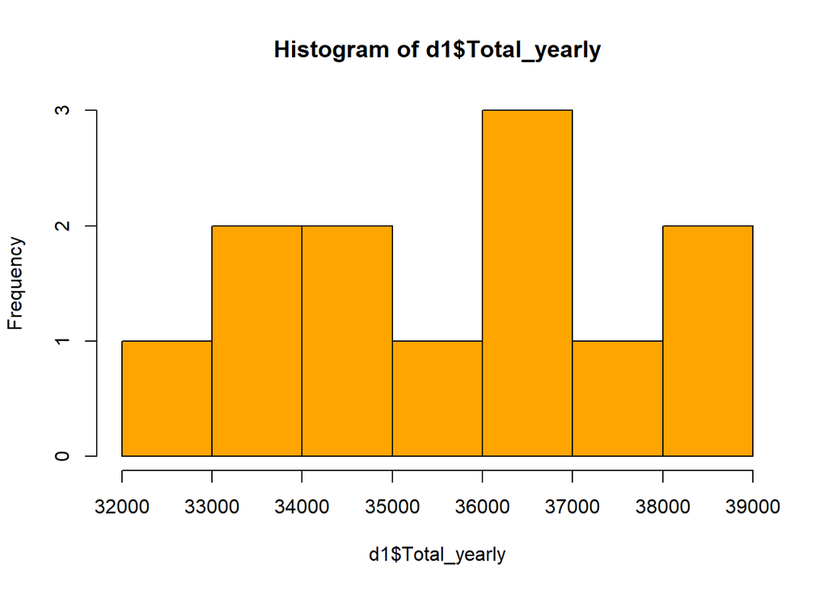

```r
hist(d1$Total_yearly, col='orange')
```

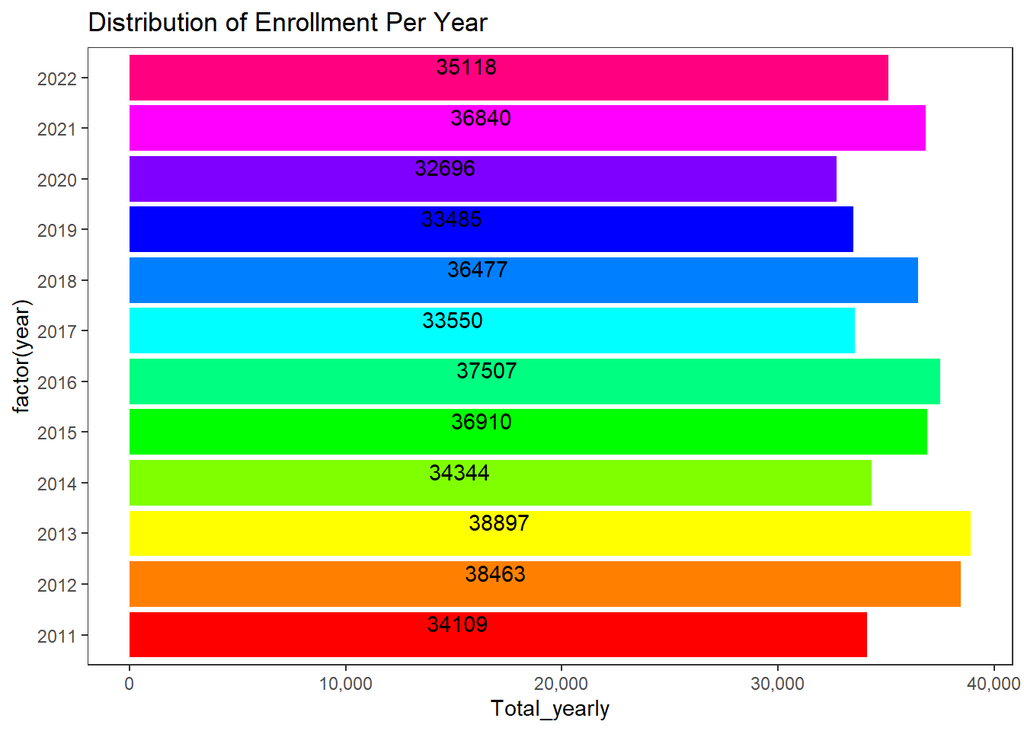

```r
p1 <- d1 %>%
  ggplot(aes(x=factor(year), y=Total_yearly))+
  geom_col(position = 'dodge', fill=rainbow(12)) +
  scale_y_continuous(labels = scales::comma)+
  geom_text(aes(label=Total_yearly),
            position = position_stack(0.4),
            vjust=-.2,
            hjust=-.04
            )+
  ggtitle('Distribution of Enrollment Per Year')+
  coord_flip()
p1
```

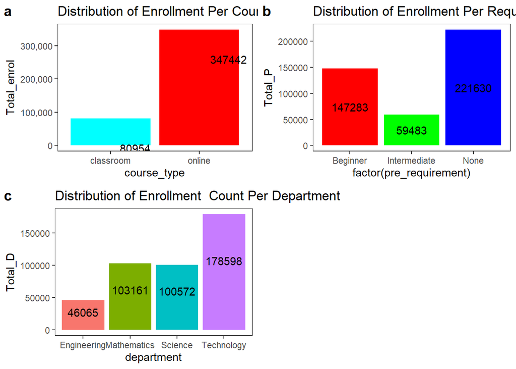

```r
d <- enrol %>%
     group_by(course_type) %>%
    summarise(Total_enrol= sum(enrollment_count)) %>%
    arrange(desc(Total_enrol))
# DT::datatable(d)

p0 <- d %>%
  ggplot(aes(x=course_type, y=Total_enrol))+
  geom_col(fill=rainbow(2)) +
  scale_y_continuous(labels = scales::comma)+
  geom_text(aes(label=Total_enrol),
            vjust=4,
            hjust=-.3
            ) +
  ggtitle('Distribution of Enrollment Per Course Type')



d2 <- enrol %>%
  group_by(pre_requirement) %>%
  summarise(Total_P=sum(enrollment_count))

p2 <- d2 %>%
  ggplot(aes(x=factor(pre_requirement), y=Total_P))+
  geom_col(fill=rainbow(3)) +
  geom_text(aes(label=Total_P),
            position = position_stack(0.5)
                        )+
  ggtitle('Distribution of Enrollment Per Requirement')

d3 <- enrol %>%
  group_by(department) %>%
  summarise(Total_D=sum(enrollment_count))
p3 <-  d3 %>%
   ggplot(aes(x=department, y= Total_D, fill=department))+
   geom_col()+
   geom_text(
     aes(label=Total_D),
     position = position_stack(0.6)
   )+
   theme(legend.position = 'none')+
   ggtitle('Distribution of Enrollment  Count Per Department')

plot_grid(p0, p2, p3, labels = "auto")
```

**In the above charts.**

-Most students prefer `Online` Classes

-When the course requirement is `NONE`, the enrollment will also goes up.

-Most students prefer `Technology` courses

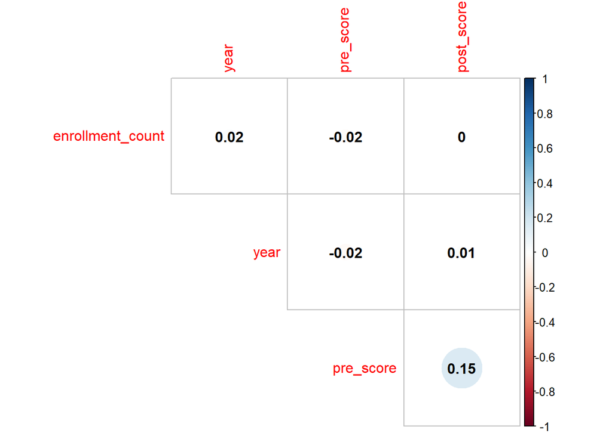

```r
enrol %>%
select(starts_with(c('enrol', 'year', 'pre_s', 'post'))) %>%
cor() %>%
corrplot(type = "upper", addCoef.col = "black", diag=FALSE)
```

We have the correlation coefficients in each box. Positive correlations are in blue. Negative correlations are in red.

r >= 0.5 large or strong association

r = 0.3 medium association

r = 0.1 small or weak association

**Summary of correlations:**

## 3. Create a visualization that shows how many courses were of each type. Use the visualization to:

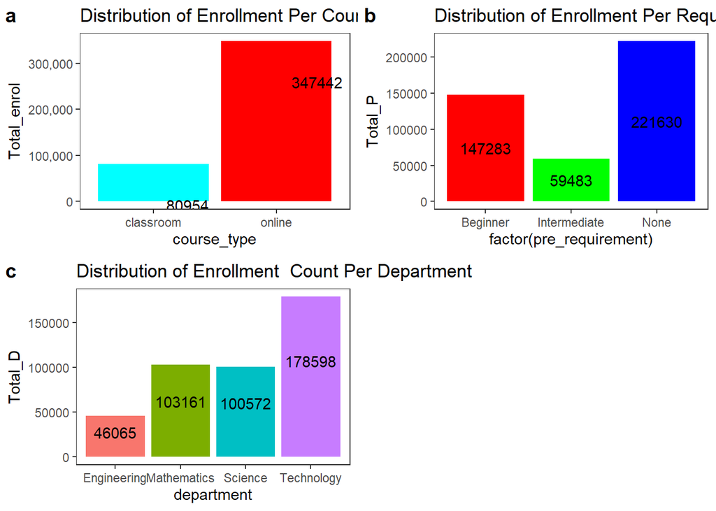

```r
plot_grid(p0, p2, p3, labels = "auto")
```

a. State which type of course has the most observations

`-Online Courses attract more number of learners`

`-Most learners prefer Technology Courses`

`-When their are NO, or NONE requirement is needed, most learners enroll.`

b. Explain whether the observations are balanced across the types.

`-The observations are not balanced at all, for instance Online enrollment is 347442 while Classroom enrollment is 80954.`

## 4. Describe the relationship between `course type` and the `enrollment count`. Your answer must include a visualization to demonstrate the relationship.

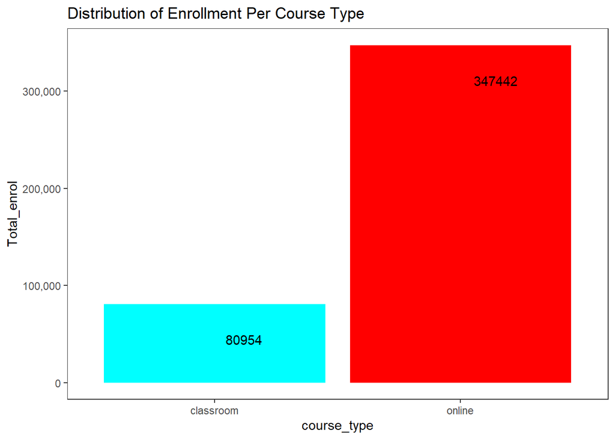

```r
d %>%
  ggplot(aes(x=course_type, y=Total_enrol))+
  geom_col(fill=rainbow(2)) +
  scale_y_continuous(labels = scales::comma)+
  geom_text(aes(label=Total_enrol),
            vjust=4,
            hjust=-.3
            ) +
  ggtitle('Distribution of Enrollment Per Course Type')
```

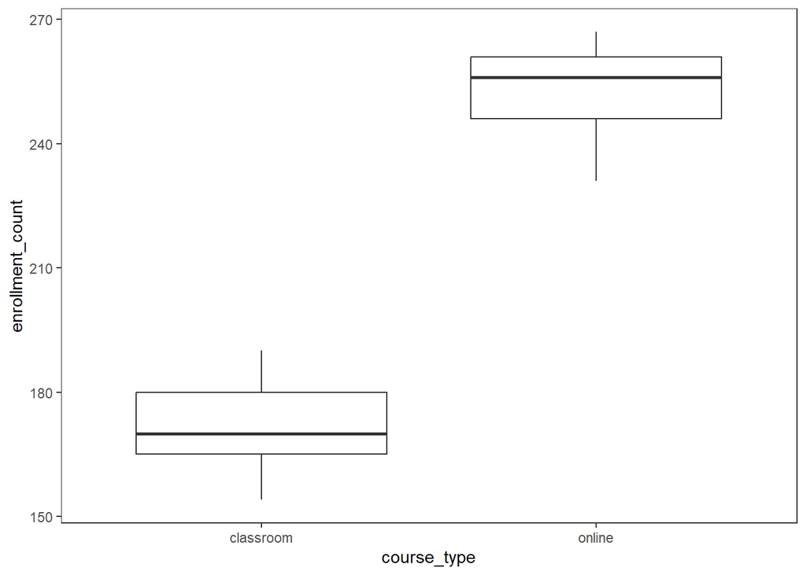

```r
enrol %>%
  ggplot(aes(course_type,enrollment_count)) +
  geom_boxplot()
```

`-Majority of learners prefer Online compared to Classroom ,`

## 5. The university wants to predict how many students will enroll in a course. State the type of machine learning problem that this is (regression/ classification/ clustering).

`-This is a Regression Problem`

# `Model Development and fitting`

## 6. Fit a baseline model to predict how many students will enroll using the data provided. You must include your code.

```r
names(enrol)
```

```
## [1] "course_id"        "course_type"      "year"             "enrollment_count"
## [5] "pre_score"        "post_score"       "pre_requirement"  "department"
```

```r
#
set.seed(13579)
#split train/test set
split <- initial_split(enrol, prop = 0.75)
train <- training(split)
test <- testing(split)
```

```r
#Base line Model
#Linear Regression Model
enrol$department1 <- NULL
enrol$course_id <- NULL
model <- lm(formula = enrollment_count~ scale(year)+scale(pre_score) +
              scale(post_score)+
              factor(course_type) + factor(pre_requirement)+
              factor(department),  data=train)
summary(model)
```

```
##
## Call:
## lm(formula = enrollment_count ~ scale(year) + scale(pre_score) +
##     scale(post_score) + factor(course_type) + factor(pre_requirement) +
##     factor(department), data = train)
##
## Residuals:
##      Min       1Q   Median       3Q      Max
## -1.20362 -0.09079 -0.03468  0.00439  2.80390
##
## Coefficients:
##                                       Estimate Std. Error  t value Pr(>|t|)
## (Intercept)                         180.038846   0.031380 5737.380  < 2e-16 ***
## scale(year)                          -0.024092   0.009153   -2.632  0.00858 **
## scale(pre_score)                     -0.003651   0.009240   -0.395  0.69283
## scale(post_score)                    -0.008622   0.009258   -0.931  0.35181
## factor(course_type)online            76.017175   0.023227 3272.770  < 2e-16 ***
## factor(pre_requirement)Intermediate -10.013049   0.028350 -353.191  < 2e-16 ***
## factor(pre_requirement)None          10.021275   0.021027  476.585  < 2e-16 ***
## factor(department)Mathematics        -9.900952   0.033682 -293.950  < 2e-16 ***
## factor(department)Science           -14.994408   0.032177 -465.999  < 2e-16 ***
## factor(department)Technology         -5.064538   0.032979 -153.571  < 2e-16 ***
## ---
## Signif. codes:  0 '***' 0.001 '**' 0.01 '*' 0.05 '.' 0.1 ' ' 1
##
## Residual standard error: 0.3392 on 1377 degrees of freedom
## Multiple R-squared:  0.9999, Adjusted R-squared:  0.9999
## F-statistic: 1.809e+06 on 9 and 1377 DF,  p-value: < 2.2e-16
```

```r
report(model)
```

```
## We fitted a linear model (estimated using OLS) to predict enrollment_count with
## year, pre_score, post_score, course_type, pre_requirement and department
## (formula: enrollment_count ~ scale(year) + scale(pre_score) + scale(post_score)
## + factor(course_type) + factor(pre_requirement) + factor(department)). The
## model explains a statistically significant and substantial proportion of
## variance (R2 = 1.00, F(9, 1377) = 1.81e+06, p < .001, adj. R2 = 1.00). The
## model's intercept, corresponding to year = 0, pre_score = 0, post_score = 0,
## course_type = classroom, pre_requirement = Beginner and department =
## Engineering, is at 180.04 (95% CI [179.98, 180.10], t(1377) = 5737.38, p <
## .001). Within this model:
##
##   - The effect of year is statistically significant and negative (beta = -0.02,
## 95% CI [-0.04, -6.14e-03], t(1377) = -2.63, p = 0.009; Std. beta = -6.55e-04,
## 95% CI [-1.14e-03, -1.67e-04])
##   - The effect of pre score is statistically non-significant and negative (beta =
## -3.65e-03, 95% CI [-0.02, 0.01], t(1377) = -0.40, p = 0.693; Std. beta =
## -9.93e-05, 95% CI [-5.92e-04, 3.94e-04])
##   - The effect of post score is statistically non-significant and negative (beta
## = -8.62e-03, 95% CI [-0.03, 9.54e-03], t(1377) = -0.93, p = 0.352; Std. beta =
## -2.35e-04, 95% CI [-7.29e-04, 2.59e-04])
##   - The effect of course type [online] is statistically significant and positive
## (beta = 76.02, 95% CI [75.97, 76.06], t(1377) = 3272.77, p < .001; Std. beta =
## 2.07, 95% CI [2.07, 2.07])
##   - The effect of pre requirement [Intermediate] is statistically significant and
## negative (beta = -10.01, 95% CI [-10.07, -9.96], t(1377) = -353.19, p < .001;
## Std. beta = -0.27, 95% CI [-0.27, -0.27])
##   - The effect of pre requirement [None] is statistically significant and
## positive (beta = 10.02, 95% CI [9.98, 10.06], t(1377) = 476.58, p < .001; Std.
## beta = 0.27, 95% CI [0.27, 0.27])
##   - The effect of department [Mathematics] is statistically significant and
## negative (beta = -9.90, 95% CI [-9.97, -9.83], t(1377) = -293.95, p < .001;
## Std. beta = -0.27, 95% CI [-0.27, -0.27])
##   - The effect of department [Science] is statistically significant and negative
## (beta = -14.99, 95% CI [-15.06, -14.93], t(1377) = -466.00, p < .001; Std. beta
## = -0.41, 95% CI [-0.41, -0.41])
##   - The effect of department [Technology] is statistically significant and
## negative (beta = -5.06, 95% CI [-5.13, -5.00], t(1377) = -153.57, p < .001;
## Std. beta = -0.14, 95% CI [-0.14, -0.14])
##
## Standardized parameters were obtained by fitting the model on a standardized
## version of the dataset. 95% Confidence Intervals (CIs) and p-values were
## computed using a Wald t-distribution approximation.
```

```r
pred <- predict(model, test) %>%
  round(0)

data.frame(Actual=test$enrollment_count,Prediction= pred)
```

|  | Actual | Prediction |
| --- | --- | --- |
| 1 | 165 | 165 |
| 2 | 246 | 246 |
| 3 | 261 | 261 |
| 4 | 257 | 256 |
| 5 | 180 | 180 |
| 6 | 247 | 246 |
| 7 | 155 | 155 |
| 8 | 165 | 165 |
| 9 | 165 | 165 |
| 10 | 251 | 251 |

[output cut: 453 more lines]

```r
caret::RMSE(pred,test$enrollment_count)
```

```
## [1] 0.2975784
```

```r
caret::R2(pred,test$enrollment_count)
```

```
## [1] 0.9999398
```

`The generic interpretation for each of our coefficients is for every one unit increase in the x variable, the y variable (enrollment_count) increases by beta units.`

What can we derive from our correlation analysis and how can we use this to inform **`enrollment_count`**?

We will just focus on the relationship between **`enrollment_count`**and each independent (x) variable. **What’s not working in `enrollment`?**

1. `Year— significant.`

`2. Department— significant`

`3. factor(pre_requirement)Intermediate — significant.`

**What is working with marketing?**

`1.Course Tpye`

`2.Pre Requirement NONE`

**What is not as impactful?**

`1. Pre score`

`2.Post score`

## 7. Fit a comparison model to predict how many students will enroll using the data provided. You must include your code.

```r
#comparison Model
#Support Vector Regression Model

model2 <- svm(formula = enrollment_count~year+pre_score +post_score+
              factor(course_type) + factor(pre_requirement)+
              factor(department),  data=train)
# summary(model2)
pred2 <- predict(model2, test) %>% round(0)

data.frame(test$enrollment_count, pred2)
```

|  | test.enrollment_count | pred2 |
| --- | --- | --- |
| 1 | 165 | 162 |
| 2 | 246 | 248 |
| 3 | 261 | 261 |
| 4 | 257 | 259 |
| 5 | 180 | 182 |
| 6 | 247 | 245 |
| 7 | 155 | 154 |
| 8 | 165 | 161 |
| 9 | 165 | 167 |
| 10 | 251 | 253 |

[output cut: 453 more lines]

```r
caret::RMSE(pred2,test$enrollment_count)
```

```
## [1] 2.334824
```

```r
caret::R2(pred2,test$enrollment_count)
```

```
## [1] 0.9962162
```

## 8. Explain why you chose the two models used in parts 6 and 7.

`I choose the Two models , so that I check the one with more accurate resulst`

## 10. Explain which model performs better and why.

**Linear Model** Performed better than **SVM. The RMSE of Linear Model is** `0.2975784` **smaller than for SVM Model at** `2.334824`